# Speed Limits and How They Affect the Severity of Injuries in Car Crashes

Yu-Hsiang Huang, Edward Lawrence, Rishi Nair

04/29/24

# Introduction

Driving is one of the most constant and necessary parts of an American’s day, and unfortunately, many accidents and crashes occur every day due to the amount of people on the road. One of the most common types of accidents to occur for drivers was speeding as found by the highways.dot.gov site showing that: “Drivers who exceed the posted speed limit are involved in nearly one-third of all fatal crashes.” From this, we felt it was important to look into how speed limits would affect the severity of crashes that people experience after an accident.

The research question we decided on is whether the severity of a person’s injury in a crash is proportional to how big or small the speed limit in an area is. The hypothesis we will be testing is that the larger a speed limit is, the more severe the injury will be, while smaller speed limits will result in little to no injury.

### Origin of Our Data

The data set we are using comes from Montgomery County of Maryland, collected via the Automated Crash Reporting System (ACRS) of the Maryland State police. This data was collected in a CSV file, hosted on the catalog.data.gov site, found as the title: “Crash Reporting - Drivers Data.”

The data set was already shown to be tidy and well organized, allowing us to easily read and understand what was being presented in the file. The set contains a collection data from 2015 to 2024, with many columns containing vasts amount of factors that could be listed for a given crash. This data could include the id of the incident, the location of the crash, the status of the driver before the accident, and weather conditions at the time of the crash.

### Extracting the Data

To explore the necessary data, we need to extract the features ‘Injury Severity’ and ‘Speed Limit’. This data will be used in visualizations and analysis to find out if there is a major correlation in the speed limits and how severe and injury in a car crash will be. The variable ‘Injury Severity’ will be out independent variable, while ‘Speed Limit’ will act as our dependent variable.

```r
library(ggplot2)
library(readr)
library(dplyr)# load packages
# Reading the data from the CSV file
crash_data <- read.csv("https://drive.google.com/uc?export=download&id=1v748QiHtEVjUoB67n4worBFm5O3YNm3J")

#Extracting 'Injury Severity' and 'Speed Limit' columns
selected_data <- crash_data %>%
  select(`Speed.Limit`, `Injury.Severity`)
```

# Summary Table

```r
library(knitr)
library(dplyr)
library(tidyr)

# Assuming you have a data frame 'crash_data' with a column 'Speed.Limit'
# Calculate summary statistics

speed_limit_summary <- selected_data %>%
  summarise(
    n = n(),
    Min = min(Speed.Limit, na.rm = TRUE),
    Q1 = quantile(Speed.Limit, 0.25, na.rm = TRUE),
    Median = median(Speed.Limit, na.rm = TRUE),
    Q3 = quantile(Speed.Limit, 0.75, na.rm = TRUE),
    Max = max(Speed.Limit, na.rm = TRUE),
    MAD = mad(Speed.Limit, na.rm = TRUE),
    SAM = mean(Speed.Limit, na.rm = TRUE), # SAM is mean for the example
    SASD = sd(Speed.Limit, na.rm = TRUE),  # SASD is std deviation for the example
  ) %>%
  # Pivot longer to have a key-value pair
  pivot_longer(cols = everything(), names_to = "Statistic", values_to = "Value")


# Assuming speed_limit_summary has been created as shown above

# Create the table using kable()
speed_limit_summary <- speed_limit_summary %>%
  mutate(across(where(is.numeric), round, 2))

speed_limit_summary_t <- t(speed_limit_summary)
speed_limit_table <- kable(speed_limit_summary_t, format = "simple", caption = "Summary Statistics for Speed Limit")

# Print the table to display in R Markdown
speed_limit_table
```

Summary Statistics for Speed Limit

| Statistic | n | Min | Q1 | Median | Q3 | Max | MAD | SAM | SASD |
| --- | --- | --- | --- | --- | --- | --- | --- | --- | --- |
| Value | 172105.00 | 0.00 | 25.00 | 35.00 | 40.00 | 75.00 | 7.41 | 32.55 | 11.06 |

#### Summary Table Analysis

The above code creates a general summary table. From the data table, we created an overall reflection of the distribution of the speed limit across these various accidents. The minimum speed limit value is 0, which could indicate that a person’s car was hit and the person who did it left the scene. The median speed limit of all crashes is roughly around 35 mph, and it falls into the Interquartile Range of 25-40. These roads could indicate back roads or state roads where most of these accidents occur, as there is usually more commotion on those roads with less room between cars. The maximum speed limit was 75, but there fewer cases of these accidents, likely indicating they were either acts of reckless driving, or a highway accident, which is rarer because cars are usually farther apart and fewer between. Vice versa, the lower speed limits likely indicate construction areas or school zones, so accidents are less likely as drivers tend to be more cautious. The distribution had a standard deviation of roughly 11, and a mean of roughly 32.55 mph on accidents. This table gives us tremendous insight into why crashes happened, if the speed limit truly played the main factor in causing the accident and more.

# Visualizations

### Histogram

Next, we will be taking each given speed limit and see if the larger numbers correlate to more crashes occurring. This will be illustrated through a histogram model, created from the ggplot2 library in R.

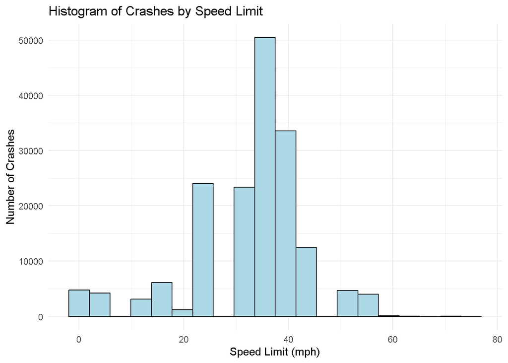

```r
# Creating a histogram of crashes by speed limit
ggplot(selected_data, aes(x = `Speed.Limit`)) +
  geom_histogram(bins = 20, fill = "lightblue", color = "black") +
  labs(title = "Histogram of Crashes by Speed Limit",
       x = "Speed Limit (mph)",
       y = "Number of Crashes") +
  theme_minimal()
```

#### Analysis

With this histogram, we can see how the most amount of crashes mostly occur when the speed limit is around 30 to 40 mph. This given a better understanding of the data we are working with, showing that we should expect more crashes around the average of what the speed limit usually is in Maryland.

### Bar Chart

Next, we want to see the relationship of the severity of injuries in regards to the speed limit and frequency of when crashes ended up taking place. We will do this using a stacked bar chart, where injury severity is the stacked variable. We will create this model by once again using the ggplot2 library, as well as data verbs such as mutate to create the stacked component.

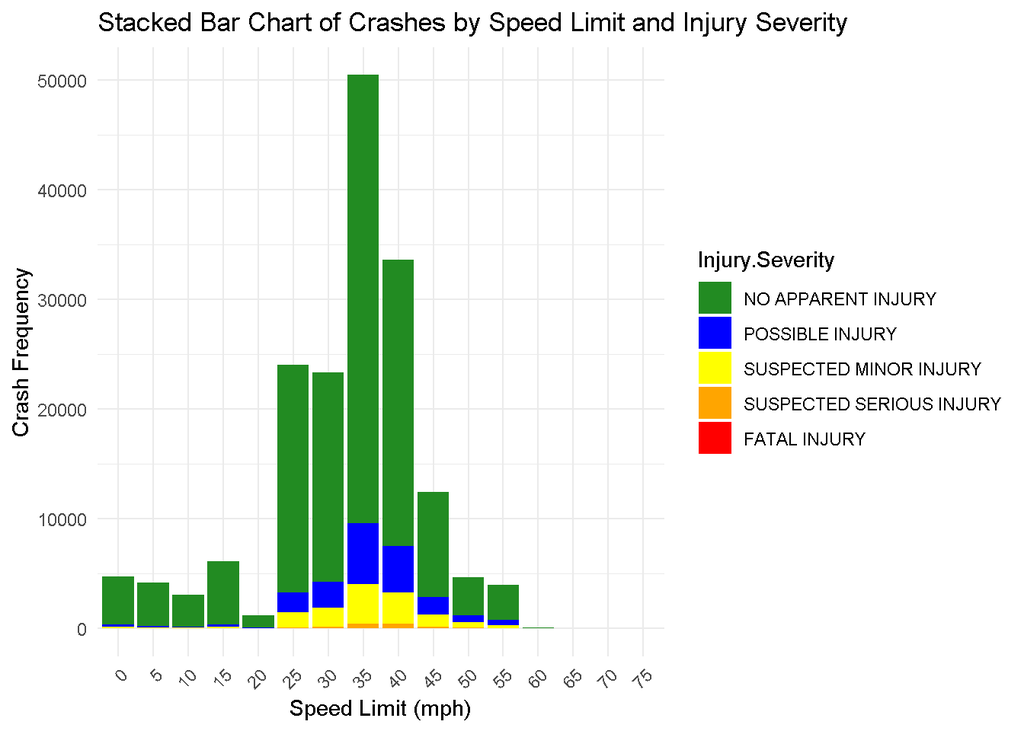

```r
# First, define the color palette
color_palette <- c("NO APPARENT INJURY" = "forestgreen",
                   "POSSIBLE INJURY" = "blue",
                   "SUSPECTED MINOR INJURY" = "yellow",
                   "SUSPECTED SERIOUS INJURY" = "orange",
                   "FATAL INJURY" = "red")

# First, we count the number of occurrences of each injury severity for each speed limit
selected_data_summary <- crash_data %>%
  count(`Speed.Limit`, `Injury.Severity`) %>%
  mutate(`Injury.Severity` = factor(`Injury.Severity`, levels = c("NO APPARENT INJURY", "POSSIBLE INJURY", "SUSPECTED MINOR INJURY", "SUSPECTED SERIOUS INJURY", "FATAL INJURY")))

# Now we can create a stacked bar chart
ggplot(selected_data_summary, aes(x = factor(`Speed.Limit`), y = n, fill = `Injury.Severity`)) +
  geom_bar(stat = "identity") +
  labs(title = "Stacked Bar Chart of Crashes by Speed Limit and Injury Severity",
       x = "Speed Limit (mph)",
       y = "Crash Frequency") +
  theme_minimal() +
  scale_fill_manual(values = color_palette) +  # Using the custom color palette
  theme(axis.text.x = element_text(angle = 45, hjust = 1))  # To prevent overlapping of x labels
```

```r
crash_frequency_by_speed_severity <- crash_data %>%
  group_by(`Speed.Limit`, `Injury.Severity`) %>%
  summarise(CrashFrequency = n(), .groups = 'drop')
```

#### Analysis

As we can see from the model, the vast majority of crash cases in Montgomery County do not result in any apparent injury, but as the frequency of crashes get higher as we move to the 30-40 mph speed limit range, we do see cases of injuries, from minor injuries to potentially major injuries. As we read our data table, we did see very few cases of fatal injuries as well, but since the frequency of that data was so insignificant, it did not end up showing up on the visualization.

### Scatter Plot

Finally, to effectively illustrate the variety of injuries that occurred at given speed limits in Maryland, we created a scatter plot with our data set. This plot was created using the ggplots2 library, using the geom_point, geom_smooth, and labs functions to display which of the variables we are testing from the data set. Each of the different points were colored accordingly, to effectively differentiate themselves from one another.

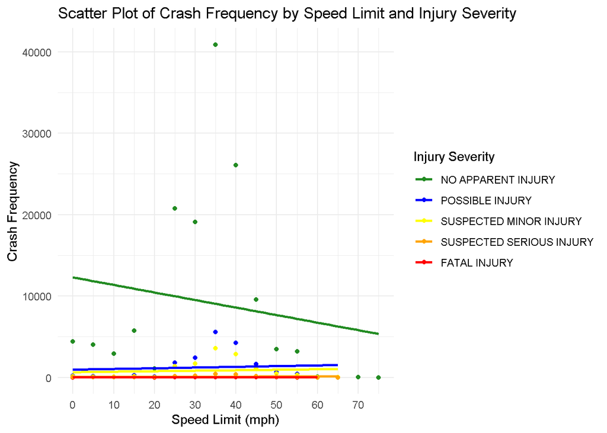

```r
# Define the order of severity levels as a factor
severity_levels <- factor(c("NO APPARENT INJURY", "POSSIBLE INJURY", "SUSPECTED MINOR INJURY", "SUSPECTED SERIOUS INJURY", "FATAL INJURY"),
                          levels = c("NO APPARENT INJURY", "POSSIBLE INJURY", "SUSPECTED MINOR INJURY", "SUSPECTED SERIOUS INJURY", "FATAL INJURY"))

# Define a custom color palette
color_palette <- c("NO APPARENT INJURY" = "forestgreen",
                   "POSSIBLE INJURY" = "blue",
                   "SUSPECTED MINOR INJURY" = "yellow",
                   "SUSPECTED SERIOUS INJURY" = "orange",
                   "FATAL INJURY" = "red")

# Scatter plot with different colors for different severity levels
ggplot(crash_frequency_by_speed_severity, aes(x = `Speed.Limit`, y = CrashFrequency)) +
  geom_point(aes(color = factor(`Injury.Severity`, levels = severity_levels))) +  # Color points by severity
  geom_smooth(method = "lm", se = FALSE, aes(color = factor(`Injury.Severity`, levels = severity_levels), group = factor(`Injury.Severity`, levels = severity_levels))) +  # Add colored regression lines with transparency
  labs(title = "Scatter Plot of Crash Frequency by Speed Limit and Injury Severity",
       x = "Speed Limit (mph)",
       y = "Crash Frequency") +
  scale_x_continuous(breaks = seq(0, 80, by = 10)) +
  theme_minimal() +
  scale_color_manual(values = color_palette) +  # Use the same custom color palette
  guides(color = guide_legend(title = "Injury Severity"))  # Add a legend title
```

# Final Thoughts

### Results

With these results, unfortunately, our hypothesis could not be supported. As even with the uptick in the severity of injuries over the increasing speed limits, the appearance of those injury severities was too small to be seen.